# Example_subchallenge2

## Example code for subchallenge 2

```r
library(tidyverse)
library(stringr) ## for str_pad() function
library(purrr) ## map
library(phangorn)
library(phylosim)
library(parallel)
library(rBayesianOptimization)
library(DCLEAR)
```

### Data Loading

Assume that we have data from subchallenge 2 data in `../data/subC2/` folder. Let's load the first file.

```r
states <- c('0', '-', LETTERS)
sequence_length <- 200L
prefix <- '../data/subC2/SubC2_train_0001'
txt_file <- sprintf('%s.txt', prefix)
nw_file <- sprintf('%s_REF.nw', prefix)

print(txt_file)
```

```
[1] "../data/subC2/SubC2_train_0001.txt"
```

Print first 5 lines to see how it looks

```r
x <- read.table(txt_file, header = FALSE, sep = '\t')
tip_names <- x[, 1]
print(x[1:5,])
```

```
      V1
1 c_0011
2 c_0170
3 c_0021
4 c_0020
5 c_0541
                                                                                                                                                                                                        V2
1 00BCAA0A00A0000A00A000A0A0000B0000A00A00000A0AA00A0A0A0000AA0AA0AD000AB0B0BAB0000A00000I000000000A00000A0A0000G000BA0A0BA0A000HA----------------CAA0C0B0D0A000A00D000000A00AC000A0000000A-------------A0
2 00A000D0A0A00A-AAAA-------------AA000BAAA0000BA0D0A0A00AA00C000C0A000A0000CE00B0AA00A0A0BAAA-BA0A00000AEABAA000ACA--------------A00C000000B00AB0AA0AA0000AAAD00B0A0000000FA0A00AD0A0000A0FA00A0A0BA000A0
3 00B0A0000D00A00A0A00AC00AA00A0000A00EB000000A0AAA00000AB0B0A00IA00A0ABAA0AI000A0A000C0AI00A0000G00000A000000B0G000000A0A000AAED000A00000E0G----------------B0AA0AE00AD000000AA000AAA0BAAA000A0000BA0AAAA
4 00B0A0A0A0AAAAAA00B000AC0B0B0A00000B00E0FB0000A0AB0AA0000BA0B00A00AA000AAE0B0A0F00A0000I0A00AAA000A0B00000A000GAA000B000000AAAA000AE00000BAB0AA0000A0A00BAA0AAA00A------------AA0AC00A0ABA00A00A000AB0A0
5 000000AD0000A000B000000I00000AA00A00000C0A00HA000AC00A0AFA0A00CAA00AA00D0A00A00000AB0BAAA0A00A000AB000B0B0AA0A00AAA00B0A0000000000A00J0A0F0A00000A0000A------------AA00AA0B0C0CAAA00AB0A0AAA0AI0AA0G000A
```

Process data and save it as `phyDat` object form

```r
states2num = 1:length(states)
names(states2num) = states

x <- do.call('rbind', strsplit(as.character(x[, 2]), ''))
rownames(x) <- tip_names

x <- x %>% phyDat(type = 'USER', levels = states)
y <- read.tree(nw_file)
```

`x` is a `phyDat` object.

```r
x
```

```
100 sequences with 200 character and 200 different site patterns.
The states are 0 - A B C D E F G H I J K L M N O P Q R S T U V W X Y Z
```

And, `y` is `phylo` object for tree.

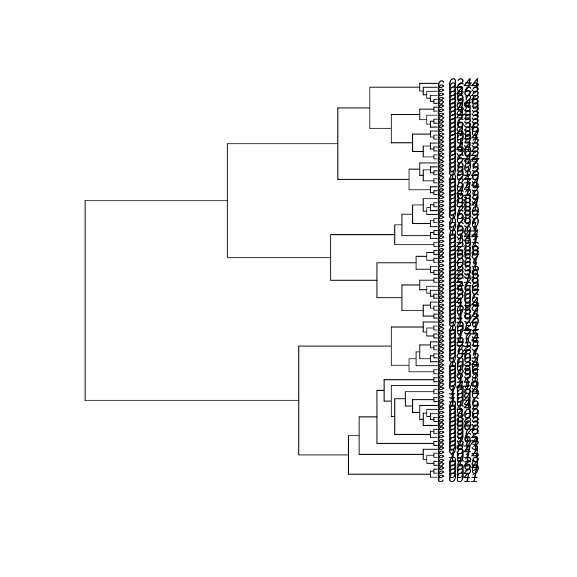

```r
plot(y)
```

Our algorithm is divided in 2 parts; `distance calculation`, and `tree reconstruction`.

For `distance calculation`, we will compare 1) hamming distance, 2) weighted hamming with entrophy weights, and 3) weighted hamming with bayesian optimization search.

For `tree reconstruction`, we will simply use Neighbor Joining (NJ) as tree reconstruction method.

### Distance claculation

The simple one is hamming distance

```r
D_h = x %>% dist.hamming()
```

D_h is a `dist` object that calculated pairwise distance among 100 cells

```r
length(D_h)
```

4950

#### Proposed Methods

We will explain how to get `dist` object using weghted hamming method. There are two methods. The first one is using Inverse information as weights. and the second one is estimating weights using bayesian optimization.

Prepare training data first

```r
set.seed(99)
idx1 = sample(100)
train_idx = idx1[1:70]
test_idx = idx1[71:100]
```

Let 70% of data as training set.

```r
SDs_train = NULL

for(i in 1:length(train_idx)) {
    idx = train_idx[i]

    states <- c('0', '-', LETTERS)
    sequence_length <- 200L
    prefix <- paste('../data/subC2/SubC2_train_',str_pad(idx,4, pad = "0"), sep="")
    txt_file <- sprintf('%s.txt', prefix)
    nw_file <- sprintf('%s_REF.nw', prefix)

    x <- read.table(txt_file, header = FALSE, sep = '\t')
    tip_names <- x[, 1]

    states2num = 1:length(states)
    names(states2num) = states

    x <- do.call('rbind', strsplit(as.character(x[, 2]), ''))
    rownames(x) <- tip_names

    x <- x %>% phyDat(type = 'USER', levels = states)
    y <- read.tree(nw_file)

    item1 = list(seq=x, tree=y)
    SDs_train[[i]] = item1
}
```

Let 30% of the data as testing set

```r
SDs_test = NULL

for(i in 1:length(test_idx)) {
    idx = test_idx[i]

    states <- c('0', '-', LETTERS)
    sequence_length <- 200L
    prefix <- paste('../data/subC2/SubC2_train_',str_pad(idx,4, pad = "0"), sep="")
    txt_file <- sprintf('%s.txt', prefix)
    nw_file <- sprintf('%s_REF.nw', prefix)

    x <- read.table(txt_file, header = FALSE, sep = '\t')
    tip_names <- x[, 1]

    states2num = 1:length(states)
    names(states2num) = states

    x <- do.call('rbind', strsplit(as.character(x[, 2]), ''))
    rownames(x) <- tip_names

    x <- x %>% phyDat(type = 'USER', levels = states)
    y <- read.tree(nw_file)

    item1 = list(seq=x, tree=y)
    SDs_test[[i]] = item1
}
```

`eval_test` is a function for evaluating our method in test set

```r
eval_test <- function(InfoW, SDs_test, dir = 'res', fnm= "v1") {
    Dwh = NULL
    Dh = NULL

    dir.create(dir, showWarnings = FALSE)

    for (i in 1:length(SDs_test)) {
        x = SDs_test[[i]][1]$seq
        y = SDs_test[[i]]$tree
        tree1 = x %>% dist_weighted_hamming(InfoW, dropout=FALSE) %>% fastme.bal()
        dist_wh = tree1 %>% RF.dist(y, normalize = TRUE)
        write.tree(tree1, paste(dir, '/Constructed_', i,'_',fnm,'.newick', sep="") )
        write.tree(y, paste(dir, '/true_', i,'_',fnm,'.newick', sep="") )
#        dist_h = x %>% dist.hamming() %>% fastme.bal() %>% RF.dist(y, normalize = TRUE)
        Dwh = c(Dwh, dist_wh)
#        Dh = c(Dh, dist_h)
        }
    return(mean(Dwh))
}
```

##### 1) Evaluate Hamming distance

```r
InfoW = rep(1,23)
#InfoW[1] = 1
#InfoW[2:23] = 1
eval_test(InfoW, SDs_test, fnm = 'hamming')
```

0.742268041237113

##### 2) Inverse information as weights

A function to calculate Inverse information from data:

```r
getInfoW <- function(SDs_train, outcome_pos=3:25, upper_bound = 7, W0 = 1, W_ = 1 ) {
    n_t = length(SDs_train)
    seqs <- rep(0,30)
    for(i in 1:n_t) {
        tb = table(unlist(SDs_train[[i]]$seq))
        for(j in names(tb)) {
            seqs[as.numeric(j)] = seqs[as.numeric(j)] + tb[j]
        }
    }
    seqs = seqs[outcome_pos]
    ws = seqs / sum(seqs)
    InfoW = -log(ws)
    InfoW[InfoW > upper_bound] = upper_bound
    InfoW = c(W0,W_,InfoW)

    return(InfoW)
}
```

Using inverse information method, we can get evaluation score as below

```r
InfoW = getInfoW(SDs_train, outcome_pos = 3:25, upper_bound = 7, W0 = 1, W_ = 1)
eval_test(InfoW, SDs_test, fnm = 'v1_1')
```

0.672508591065292

##### 3) estimating weights using bayesian optimization

Assume two different weights, weights for interval dropout, `Wdropout`, and weight for other outcome states `Wothers`.

```r
WHfit <- function( Wdropout, Wothers ) {

    InfoW = rep(1,7)
    InfoW[1] = 1
    InfoW[2] = Wdropout
    InfoW[3:23] = Wothers

    ds = NULL
    for(i in 1:length(SDs_train)){
        D_wh = dist_weighted_hamming(SDs_train[[i]][1]$seq, InfoW, dropout = FALSE)
        tree_wh = fastme.bal(D_wh)
        ds = c(ds, -RF.dist(tree_wh, SDs_train[[i]]$tree, normalize = TRUE) )
    }

    result = list( Score = mean(ds), Pred = 0 )
    return(result)

}


search_bound <- list(Wdropout = c(0.1,1),
                     Wothers = c(1, 15)  )


set.seed(123)
search_grid <- data.frame(Wdropout = runif(30, 0.1, 1.5),
                          Wothers = runif(30, 1.5, 15))

head(search_grid)
```

A data.frame: 6 × 2

|  | Wdropout <dbl> | Wothers <dbl> |
| --- | --- | --- |
| 1 | 0.5026085 | 14.500827 |
| 2 | 1.2036272 | 13.681037 |
| 3 | 0.6725677 | 10.824521 |
| 4 | 1.3362244 | 12.238810 |
| 5 | 1.4166542 | 1.832285 |
| 6 | 0.1637791 | 7.950246 |

```r
set.seed(123)
bayes_WH <- BayesianOptimization(FUN = WHfit, bounds = search_bound,
                     init_points = 0, init_grid_dt = search_grid,
                     n_iter = 30, acq = "ucb")
```

```
elapsed = 2.52	Round = 1	Wdropout = 0.5026	Wothers = 14.5008	Value = -0.8021
elapsed = 2.35	Round = 2	Wdropout = 1.2036	Wothers = 13.6810	Value = -0.7948
elapsed = 2.42	Round = 3	Wdropout = 0.6726	Wothers = 10.8245	Value = -0.7885
elapsed = 2.30	Round = 4	Wdropout = 1.3362	Wothers = 12.2388	Value = -0.7901
elapsed = 1.86	Round = 5	Wdropout = 1.4167	Wothers = 1.8323	Value = -0.7065
elapsed = 2.38	Round = 6	Wdropout = 0.1638	Wothers = 7.9502	Value = -0.7772
elapsed = 2.48	Round = 7	Wdropout = 0.8393	Wothers = 11.7392	Value = -0.7920
elapsed = 2.22	Round = 8	Wdropout = 1.3494	Wothers = 4.4215	Value = -0.7078
elapsed = 2.31	Round = 9	Wdropout = 0.8720	Wothers = 5.7954	Value = -0.7411
elapsed = 2.25	Round = 10	Wdropout = 0.7393	Wothers = 4.6269	Value = -0.7214
elapsed = 1.99	Round = 11	Wdropout = 1.4396	Wothers = 3.4278	Value = -0.6854
elapsed = 2.34	Round = 12	Wdropout = 0.7347	Wothers = 7.0964	Value = -0.7611
elapsed = 2.36	Round = 13	Wdropout = 1.0486	Wothers = 7.0853	Value = -0.7555
elapsed = 2.20	Round = 14	Wdropout = 0.9017	Wothers = 6.4794	Value = -0.7549
elapsed = 2.15	Round = 15	Wdropout = 0.2441	Wothers = 3.5580	Value = -0.7065
elapsed = 1.99	Round = 16	Wdropout = 1.3598	Wothers = 3.3739	Value = -0.6865
elapsed = 2.25	Round = 17	Wdropout = 0.4445	Wothers = 4.6460	Value = -0.7270
elapsed = 2.29	Round = 18	Wdropout = 0.1589	Wothers = 7.7905	Value = -0.7758
elapsed = 2.18	Round = 19	Wdropout = 0.5591	Wothers = 5.0906	Value = -0.7321
elapsed = 2.39	Round = 20	Wdropout = 1.4363	Wothers = 13.0807	Value = -0.7882
elapsed = 1.82	Round = 21	Wdropout = 1.3454	Wothers = 2.1187	Value = -0.6866
elapsed = 2.39	Round = 22	Wdropout = 1.0699	Wothers = 7.4697	Value = -0.7585
elapsed = 2.35	Round = 23	Wdropout = 0.9967	Wothers = 12.2855	Value = -0.7920
elapsed = 2.00	Round = 24	Wdropout = 1.4920	Wothers = 3.1456	Value = -0.6820
elapsed = 2.38	Round = 25	Wdropout = 1.0180	Wothers = 9.0728	Value = -0.7736
elapsed = 2.19	Round = 26	Wdropout = 1.0919	Wothers = 4.2882	Value = -0.7066
elapsed = 2.05	Round = 27	Wdropout = 0.8617	Wothers = 3.2217	Value = -0.6791
elapsed = 2.44	Round = 28	Wdropout = 0.9318	Wothers = 11.6697	Value = -0.7922
elapsed = 2.38	Round = 29	Wdropout = 0.5048	Wothers = 13.5831	Value = -0.8019
elapsed = 2.32	Round = 30	Wdropout = 0.3060	Wothers = 6.5552	Value = -0.7610
elapsed = 1.99	Round = 31	Wdropout = 0.9995	Wothers = 2.7991	Value = -0.6594
elapsed = 2.02	Round = 32	Wdropout = 0.3440	Wothers = 2.6643	Value = -0.6739
elapsed = 1.91	Round = 33	Wdropout = 0.7458	Wothers = 2.6994	Value = -0.6604
elapsed = 2.17	Round = 34	Wdropout = 0.1000	Wothers = 3.0080	Value = -0.6982
elapsed = 1.99	Round = 35	Wdropout = 0.1000	Wothers = 2.0411	Value = -0.6751
elapsed = 2.08	Round = 36	Wdropout = 0.1000	Wothers = 1.5006	Value = -0.6884
elapsed = 2.13	Round = 37	Wdropout = 0.4597	Wothers = 1.0000	Value = -0.7028
elapsed = 1.93	Round = 38	Wdropout = 1.0000	Wothers = 2.5898	Value = -0.6521
elapsed = 2.00	Round = 39	Wdropout = 0.5456	Wothers = 2.3489	Value = -0.6523
elapsed = 2.09	Round = 40	Wdropout = 0.1000	Wothers = 2.3258	Value = -0.6806
```

[output cut: 8 more lines]

```
elapsed = 2.06	Round = 49	Wdropout = 0.5421	Wothers = 3.1763	Value = -0.6835
elapsed = 2.01	Round = 50	Wdropout = 0.3021	Wothers = 1.4084	Value = -0.6717
elapsed = 2.04	Round = 51	Wdropout = 0.2370	Wothers = 2.1040	Value = -0.6700
elapsed = 1.98	Round = 52	Wdropout = 0.8909	Wothers = 2.6161	Value = -0.6566
elapsed = 1.97	Round = 53	Wdropout = 0.7567	Wothers = 1.0000	Value = -0.7256
elapsed = 1.88	Round = 54	Wdropout = 0.5812	Wothers = 1.9596	Value = -0.6436
elapsed = 1.94	Round = 55	Wdropout = 0.5275	Wothers = 2.0774	Value = -0.6493
elapsed = 1.87	Round = 56	Wdropout = 0.7054	Wothers = 2.3754	Value = -0.6515
elapsed = 2.04	Round = 57	Wdropout = 0.4600	Wothers = 2.0294	Value = -0.6507
elapsed = 1.97	Round = 58	Wdropout = 0.5236	Wothers = 2.1701	Value = -0.6473
elapsed = 1.93	Round = 59	Wdropout = 0.5310	Wothers = 2.0294	Value = -0.6457
elapsed = 2.01	Round = 60	Wdropout = 0.5580	Wothers = 2.1510	Value = -0.6476

 Best Parameters Found:
Round = 46	Wdropout = 0.5835	Wothers = 1.8797	Value = -0.6430
```

With Bayesian hyperparameter optimization, we get estimates for `Wdropout` and `Wothers`. Put these estimates as wegiht and get the evaluation performance.

```r
InfoW = rep(1,7)
InfoW[1] = 1
InfoW[2] = 0.5835
InfoW[3:23] = 1.8797

eval_test(InfoW, SDs_test, fnm = 'v1_2')
```

0.637457044673539